# Introduction of using shinyTempSignal

Guangchuang Yu School of Basic Medical Sciences, Southern Medical University

2024-03-06

## Introduction

Detecting temporal signals of a phylogenetic tree is crucial for estimating divergence times and ccan also serve as a data quality control measure before applying molecular clock models. The shinyTempSignal package implemntes temporal signal analysis under both strict and relaxed molecular clock assumptions and allows exploring temporal signals across the entire tree as well as within different lineages.

ShinyTempSignal allows regression analysis of various types of data, including measurable biological traits and statistical values obtained from evolutionary analysis. Such a versatile regression analysis is highly beneficial for discovering potential evolutionary patterns and addressing biological questions.

Implementing using R shiny, shinyTempSignal provides an interactive interface that allows users to visualize analysis results in real-time and explore data easily.

If you use shinyTempSignal in published research, please cite the following paper:

- L Zhan<sup>#</sup>, X Luo<sup>#</sup>, W Xie<sup>#</sup>, XA Zhu<sup>#</sup>, Z Xie, J Lin, L Li, W Tang, R Wang, L Deng, Y Liao, B Liu, Y Cai, Q Wang, Shuangbin Xu*, **G Yu***. *shinyTempSignal*: an R shiny application for exploring temporal and other phylogenetic signals. *Journal of Genetics and Genomics*. 2024, doi: 10.1016/j.jgg.2024.02.004.

## Installation

shinyTempSignal is available in CRAN and user can use the following command to install it:

```r
install.packages("shinyTempSignal")
```

## Run the shiny application

After loading the package, users can use the `run_shinyTempSignal()` command to launch the shiny application.

```r
library(shinyTempSignal)
run_shinyTempSignal()
```

## Interactive Web Interface

### Tree structure exploration panel

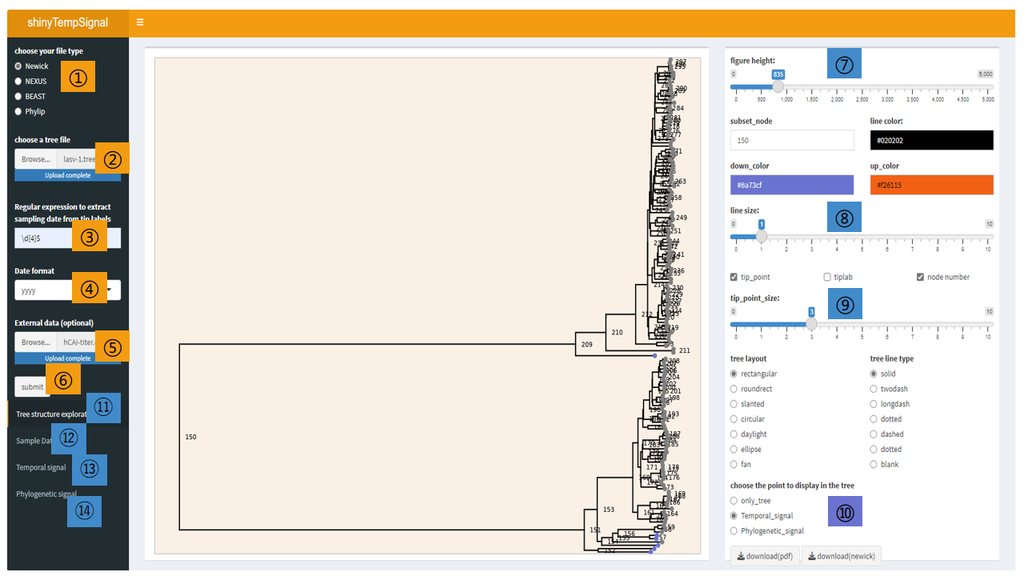

**Exploring tree structure.** Users need to upload a tree file and a corresponding regular expression to extract sampling dates from tip labels through steps (1-6); users can modify the tree plot appearance (7-9) and select using temporal or phylogenetic signals for detecting outliers (10) which will be shown in a different color of tip points; different panels (11-14) can be selected to present different analysis results.

### Sample date panel

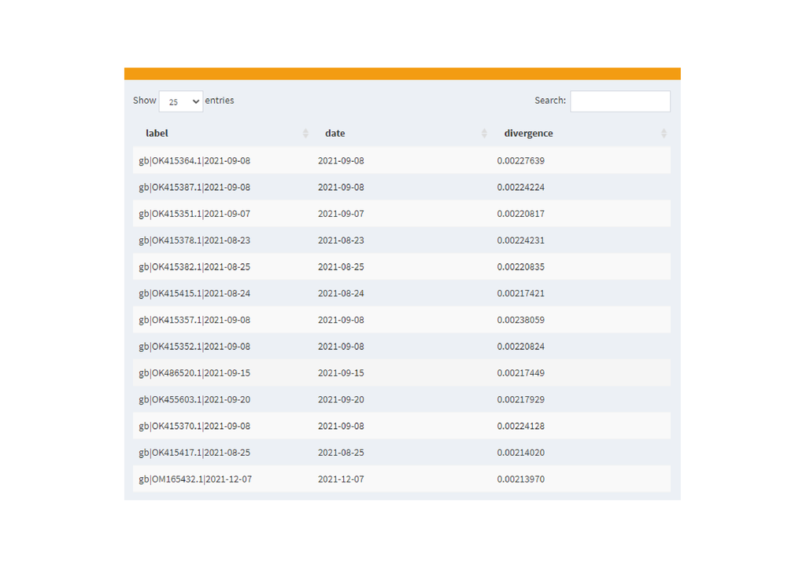

**Exploring sampling dates.** This panel is used to present the sampling dates extracted from the tip labels of the tree and the divergence from the tip to the root will also be calculated.